# Vignette Title

### Figure 1d

#### Introduction

In order to define the 3’ transcription stop site for the miR34a asRNA, 3’-RACE was performed.

#### Methods

All cell lines were cultured at 5% CO2 and 37° C with U2OS cells grown in McCoy’s 5a (Life Technologies). All growth mediums were supplemented with 10% heat-inactivated FBS and 50 μg/ml of streptomycin and 50 μg/ml of penicillin. U2OS cell RNA was polyA-tailed using yeast polyA polymerase after which cDNA was synthesized using oligo(dT) primers. Nested-PCR was performed first using a forward primer in miR34a asRNA exon 1 (miR-34a asRNA F10 forward primer - ACGCGTCTCTCCAGCCCGGGAT) and a tailed oligo(dT) primer (poly T T7-FAM) followed by a second PCR using an alternate miR34a asRNA exon 1 primer (miR-34a asRNA F1 forward primer - AGCGGCATCTCCTCCACCTGAAA) and a reverse primer binding to the tail of the previously used oligo(dT) primer (FAM primer). PCR products were gel purified and cloned the Strata Clone Kit (Agilent Technologies), and sequenced.

#### Results

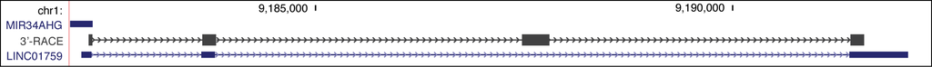

```r
url <- "3primeRACE/results_hg38.png"
knitr::include_graphics(file.path(projectUrl, url))
```

3’-RACE sequencing results displayed in the UCSC genome browser together with the annotated miR34a asRNA transcript from GENCODE.

#### Conclusions

Sequencing of the resulting cloned cDNA indicated the transcripts 3’ transcription termination site to be 125bp upstream of the RP3-510D11.2 transcript’s annotated termination site.

### Figure 1e

#### Introduction

We desired to determine the 5’-start site for the miR34a asRNA.

#### Methods

To accomplish this we performed the primer walk assay. All cell lines were cultured at 5% CO2 and 37° C with HEK293T cells cultured in DMEM high glucose (Hyclone). All growth mediums were supplemented with 10% heat-inactivated FBS and 50 μg/ml of streptomycin and 50 μg/ml of penicillin. RNA was extracted using the RNeasy mini kit (Qiagen) and subsequently treated with DNase (Ambion Turbo DNA-free, Life Technologies). 500ng RNA was used for cDNA synthesis using MuMLV (Life Technologies) and a 1:1 mix of oligo(dT) and random nanomers. PCR was performed for 35 cycles at 62°C annealing temperature and the resulting products were analyzed on a 2% agarose gel.

##### Primers

```r
primers <- data.frame(
    name=c(
        "miR34aAS_F10",
        "miR34aAS_F11",
        "miR34aAS_F12",
        "miR34aAS_F13",
        "miR34aAS_F14",
        "miR34aAS_F15",
        "miR34aAS_R1"
    ),
    sequence=c(
        "ACG CGT CTC TCC AGC CCG GGA T",
        "ATC TGC GTG GTC ACC GAG AAG CA",
        "CGC ACG GAC TGA GAA ACA CAA G",
        "ACG GAG GCT ACA CAA TTG AAC AGG",
        "AGG GAA GAA AGA ACT AGC CGA GCA",
        "CAT TTG CTG CAA TAT CAC CGT GGC",
        "TTG CCT CGT GAG TCC AAG GAG AAT"
    )
)
primers
```

| name | sequence |
| --- | --- |
| miR34aAS_F10 | ACG CGT CTC TCC AGC CCG GGA T |
| miR34aAS_F11 | ATC TGC GTG GTC ACC GAG AAG CA |
| miR34aAS_F12 | CGC ACG GAC TGA GAA ACA CAA G |
| miR34aAS_F13 | ACG GAG GCT ACA CAA TTG AAC AGG |
| miR34aAS_F14 | AGG GAA GAA AGA ACT AGC CGA GCA |
| miR34aAS_F15 | CAT TTG CTG CAA TAT CAC CGT GGC |
| miR34aAS_R1 | TTG CCT CGT GAG TCC AAG GAG AAT |

#### Results

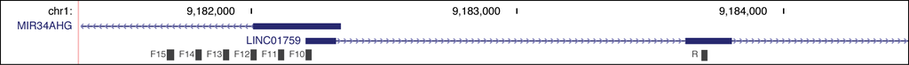

```r
url <- "primerWalk/schematic_hg38.png"
knitr::include_graphics(file.path(projectUrl, url))
```

A schematic picture of the miR34a asRNA locus including the location of the primers used in the primer walk assay.

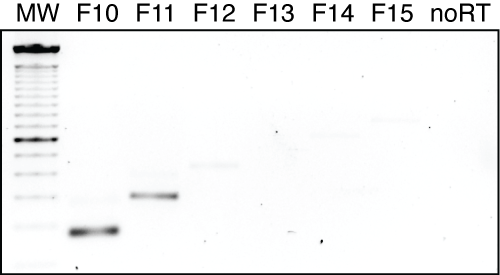

```r
url <- "primerWalk/gel.png"
knitr::include_graphics(file.path(projectUrl, url))
```

The semi-quantitative PCR results from the primer walk assay performed using HEK293T cells.

#### Conclusion

It appears as though the miR34a asRNA transcript start site is somewhat upstream of the annotated start site. Although there is some product present for the F12 primer, the majority of transcription seems to be originating from the F11 primer. This indicates that the start site is between 71-224bp upstream of the annotated start site.

#### Introduction

We utilized a bioinformatic approach to evaluate the coding potential of the miR34a asRNA transcript. The Coding-potential assessment tool uses a linear regression model to evaluate coding-potential by examining ORF length, ORF coverage, Fickett score and hexamer score. We further confirmed these results using the Coding-potential Calculator which utilizes a support based machine-based classifier and accesses an alternate set of discriminatory features.

#### Methods

Protein-coding capacity was evaluated using the [Coding-potential Assessment Tool](https://www.ncbi.nlm.nih.gov/pmc/articles/PMC3616698/) and [Coding-potential Calculator](https://www.ncbi.nlm.nih.gov/pmc/articles/PMC1933232/) with default settings. Transcript sequences for use with Coding-potential Assessment Tool were downloaded from the UCSC genome browser using the following IDs: HOTAIR (ENST00000455246.1), XIST (ENST00000429829.1), β-actin (ENST00000331789.5), Tubulin (ENST00000427480.1), and MYC (ENST00000377970). Transcript sequences for use with Coding-potential Calculator were downloaded from the UCSC genome browser using the following IDs: HOTAIR (uc031qho.1), β-actin (uc003soq.4).

#### Results

##### Coding Potential Assesment Tool

```r
url <- "codingPotential/CodingPotentialAssessmentTool/results.txt"
cpat <-read.table(url(file.path(projectUrl, url)), header = TRUE, sep = "\t")
cpat
```

| sequenceName | RNAsize | ORFsize | FicketScore | hexamerScore | codingProbability | codingLabel |
| --- | --- | --- | --- | --- | --- | --- |
| miR34a asRNA | 795 | 285 | 0.801 | 0.258 | 0.301 | no |
| HOTAIR | 918 | 144 | 0.919 | 0.268 | 0.126 | no |
| XIST | 19280 | 411 | 0.663 | -0.128 | 0.027 | no |
| β-actin | 1917 | 1128 | 1.350 | 0.698 | 1.000 | yes |
| Tubulin | 2632 | 1119 | 1.277 | 0.515 | 1.000 | yes |
| MYC | 2345 | 1320 | 1.223 | 0.484 | 1.000 | yes |

Coding potential analysis results from the Coding-potential Assessment Tool including miR34a asRNA and two characterized non-coding transcripts (HOTAIR and XIST) and 3 known coding transcripts (β-actin, tubulin, and MYC).

##### Coding Potential Calculator

```r
url <- "codingPotential/CodingPotentialCalculator/results.txt"
cpc <- read.table(url(file.path(projectUrl, url)), header = TRUE, sep = "\t")
cpc
```

| Transcript.name | Coding | Coding.Potential.Score | Hit.number | Hit.score | Frame.score | Length | Coverage…. | Log.Odds.score | Type |
| --- | --- | --- | --- | --- | --- | --- | --- | --- | --- |
| HOTAIR | noncoding | -1.187350 | 0 | 0.0000 | 0.00000 | 319 | 13.43 | 32.91 | full |
| miR34a asRNA | noncoding (weak) | -0.883468 | 0 | 0.0000 | 0.00000 | 175 | 21.89 | 42.47 | full |
| β-actin | coding | 13.662000 | 250 | 181.3849 | 34.26889 | 1167 | 62.82 | 229.54 | full |

Coding potential analysis results using the Coding-potential calculator for miR34a asRNA, HOTAIR, and β-actin.

#### Conclusions

Results indicated that miR34a asRNA has a similar lack of coding capacity to the known non-coding transcripts HOTAIR and XIST and differs greatly when examining these parameters to the known coding transcripts beta-actin, tubulin, and MYC. However, to fully evaluate coding potential methods such as mass spectrometry or ribosome profiling must be used.

### Figure 2a

#### Introduction

miR34a is a known downstream target of p53 and has been previously shown to exhibit increased expression with cellular apoptotic signaling. We hypothesized that miR34a asRNA may be regulated in a similar fashion whereby transcription is stimulated by activation of p53. To test this we treated p53+/+ and p53-/- HCT116 cells with increasing concentrations of the DNA damaging agent doxorubicin and monitored miR34a asRNA expression.

#### Methods

HCT116 cells were cultured in DMEM high modified (Hyclone, GE healthcare) supplemented with supplemented with 2mM L-glutamine, 50ug/ml Penicillin-Streptomycin and 10% Fetal Calf Serum.  
25 x 10^5 HCT116 cells were plated in 6 well plates. 24 hours later media was exchanged and doxorubicin was added to a final concentration of 100, 200 or 500 ng/ml. Cells were harvested for RNA extraction 24 hours later using trypsin. RNA was extracted using Nucleospin RNA kit (Machery-Nagel Ref. 740955) according to manufacturer‟s protocol and DNase treated using Ambion Turbo DNA-free according to manufacturer‟s protocol (Life Technologies Ref. AM1907). cDNA was synthesized using ~500 ng RNA with M-MLV (Life Technologies Ref 28025013) and a mixture of oligo(dT) with nanomers in accordance with the manufacturer’s protocol. qPCR quantification was carried out using the PowerUp SYBR Green Master Mix (Thermo Fisher Scientific, Ref. A25777) on the CFX96 Touch Real-Time PCR Detection System: 50°C for 2 min, 95°C for 2min, and 95°C for 1 sec followed by 60°C for 30 sec repeated for 40 cycles. The following primers were used:

##### Primers

```r
primers <- data.frame(
    name=c(
        "ß-actin Fwd",
        "ß-actin Rev",
        "miR34a HG_F",
        "miR34a HG_R",
        "miR34a_asF1",
        "miR34a_asR1"

    ),
    sequence=c(
        "AGGTCATCACCATTGGCAATGAG",
        "CTTTCGGGATGTCCACGTCA",
        "TCTGCTCCAGTGGCTGATGAGAAA",
        "GTTCACTGGCCTCAAAGTTGGCAT",
        "AGCGGCATCTCCTCCACCTGAAA",
        "TTGCCTCGTGAGTCCAAGGAGAAT"

    )
)
primers
```

[output not shown]

#### Results

Perform ddct analysis and statistical testing.

```r
#download and format data
url <- "HCT116p53null.rda"
repmis::source_data(file.path(dataUrl, url))
```

```
## SHA-1 hash of the downloaded data file is:
## 2f3495af60d2b38454ecad092a9da798fafab11d
```

```
## [1] "."
```

```r
data <- .

#calculate dct
groups <- c("Condition", "Treatment", "Biological Replicate", "Cell line", "gene")
gois <- c("miR34a asRNA", "miR34a HG")

data <- technicalMeans(data, groups) %>%
  dct(., gois, Actin, groups)

#calculate ddct
groups[groups == "gene"] <- "GOI"
logical <- tibble(
  Treatment = data$Treatment == 0
)

data <- data %>%
  ddct(., logical, groups) %>%
  folds(.)

#calculate stats
stats <- calcStats(data, Condition, "p53-wt", groups) %>%
  pFormat(.)

#setup plotting variables
stats <- stats %>%
  group_by(GOI, Treatment) %>%
  mutate(
    max = max(CI95h),
    x = case_when(
      Treatment ==   0 ~ 1 + 0.25,
      Treatment == 100 ~ 2 + 0.25,
      Treatment == 200 ~ 3 + 0.25,
      Treatment == 500 ~ 4 + 0.25
    ),
    xend = case_when(
      Treatment ==   0 ~ 1 - 0.25,
      Treatment == 100 ~ 2 - 0.25,
      Treatment == 200 ~ 3 - 0.25,
      Treatment == 500 ~ 4 - 0.25
    )
  ) %>%
  ungroup()
```

Plot the results.

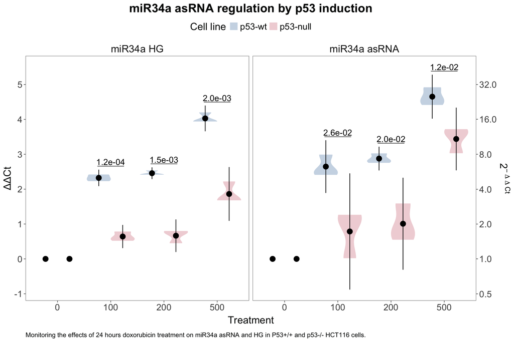

```r
#plot for Rmarkdown
ggplot(data = NULL) +
    geom_violin(
        data = data,
        aes(x = Treatment, y = log2fold, fill = Condition),
        trim = TRUE,
        alpha = 0.3,
        color = NA,
        scale = "width",
        show.legend = TRUE
    ) +
    geom_point(
        data = stats,
        aes(x = Treatment, y = mean, group = Condition),
        position = position_dodge(width = 0.9),
        size = 4
    ) +
    facet_grid(. ~ GOI) +
    geom_linerange(
        data = stats,
        aes(x = Treatment, ymin = CI95l, ymax = CI95h, group = Condition),
        colour = "black",
        position = position_dodge(width = 0.9),
        show.legend = FALSE
    ) +
    geom_label(
        data = stats,
        aes(x = Treatment, y = max + 0.22, label = pFormat),
        label.size = 0,
        label.padding = unit(0.01, "lines"),
        show.legend = FALSE,
        fill = "white",
        size = 5,
        family = "Arial Unicode MS",
        position = position_dodge(width = 0.9)
    ) +
    geom_segment(
        data = stats,
        aes(x = x, y = max + 0.1, xend = xend, yend = max + 0.1),
        colour="grey43",
        show.legend = FALSE
    ) +
    scale_y_continuous(
        "\u0394\u0394Ct",
        breaks=c(-1,0,1,2,3,4,5),
        sec.axis = sec_axis(
            ~2^.,
            name = expression(2^{- ~ Delta ~ Delta ~ "Ct"}),
            breaks=c(2^-1,2^0,2^1,2^2,2^3,2^4,2^5)
        )
    )+
    labs(
      x="Treatment",
      title="miR34a asRNA regulation by p53 induction",
      caption=
            "Monitoring the effects of 24 hours doxorubicin treatment on miR34a asRNA and HG in P53+/+ and p53-/- HCT116 cells."
    )+
    theme_few()+
    scale_fill_ptol()+
    scale_colour_ptol()+
    #values=c("#014d64", "#6794a7")
    theme(
        plot.title = element_text(
            hjust = 0.5,
            face="bold",
            size=20
        ),
        plot.caption = element_text(
            hjust=0,
            margin=margin(t=15),
            family="Arial Unicode MS"
        ),
        legend.position = "top",
        legend.title=element_text(size=17),
        legend.text=element_text(size=15),
        axis.title=element_text(size=17),
        axis.title.x=element_text(margin=margin(t=10)),
        axis.text=element_text(size=15),
        strip.text.x=element_text(size=17)
    )+
    guides(fill = guide_legend(title = "Cell line", override.aes = list(size=3)))
```

#### Conclusions

We observed increasing miR34a HG and asRNA expression with increasing doses of doxorubicin indicating that these two transcripts are co-regulated by p53. Although p53+/+ cells showed a 25-fold increase over untreated cells in miR34a AS expression at the highest tested doxorubicin concentration, this effect was largely abrogated, 11 fold over untreated, in p53-/- cells, indicating that p53 is a major regulator of miR34a asRNA expression.

### Figure 2b

#### Introduction

miR34a is a known downstream target of p53 and has been previously shown to exhibit increased expression with cellular apoptotic signaling. We hypothesized that miR34a asRNA may be regulated in a similar fashion whereby transcription is stimulated by activation of p53. To test this we treated HCT116 and HEK293t cells with 200 ng/ml of the DNA damaging agent doxorubicin for 24 hours and monitored miR34a asRNA expression.

#### Methods

```r
primers <- data.frame(
    name=c(
        "ß-actin Fwd",
        "ß-actin Rev",
        "miR34a HG_F",
        "miR34a HG_R",
        "miR34a_asF1",
        "miR34a_asR1"

    ),
    sequence=c(
        "AGGTCATCACCATTGGCAATGAG",
        "CTTTCGGGATGTCCACGTCA",
        "TCTGCTCCAGTGGCTGATGAGAAA",
        "GTTCACTGGCCTCAAAGTTGGCAT",
        "AGCGGCATCTCCTCCACCTGAAA",
        "TTGCCTCGTGAGTCCAAGGAGAAT"

    )
)
primers
```

| name | sequence |
| --- | --- |
| ß-actin Fwd | AGGTCATCACCATTGGCAATGAG |
| ß-actin Rev | CTTTCGGGATGTCCACGTCA |
| miR34a HG_F | TCTGCTCCAGTGGCTGATGAGAAA |
| miR34a HG_R | GTTCACTGGCCTCAAAGTTGGCAT |
| miR34a_asF1 | AGCGGCATCTCCTCCACCTGAAA |
| miR34a_asR1 | TTGCCTCGTGAGTCCAAGGAGAAT |

#### Results

```r
url <- "HctHekDox.rda"
repmis::source_data(file.path(dataUrl, url))
```

```
## SHA-1 hash of the downloaded data file is:
## 54d24343591ee15b1c076723db38cb02b5142b4e
```

```
## [1] "."
```

```r
data <- .

#calculate dct
groups <- c("Treatment", "Biological Replicate", "Cell line", "gene")
gois <- c("miR34a asRNA", "miR34a HG")

data <- technicalMeans(data, groups) %>%
  dct(., gois, Actin, groups)

#calculate ddct
groups[groups == "gene"] <- "GOI"
logical <- tibble(
  `Biological Replicate` = pull(data, `Biological Replicate`) == 1,
  Treatment = pull(data, Treatment) == "untreated"
)

data <- data %>%
  ddct(., logical, groups) %>%
  folds(.)

#calculate stats
stats <- calcStats(data, Treatment, "untreated", groups) %>%
  pFormat(.)
```

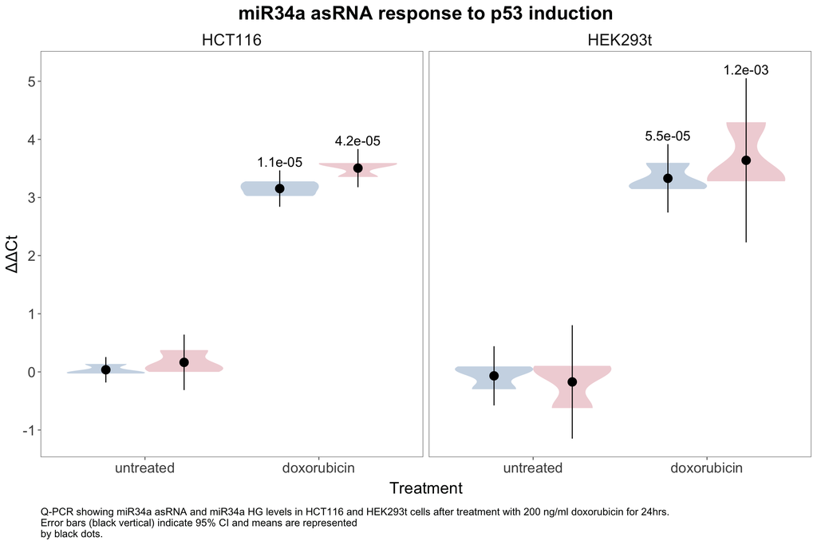

```r
#plot for Rmarkdown
ggplot(data = NULL) +
  geom_violin(
    data = data,
    aes(x = Treatment, y = log2fold, fill = GOI),
    trim = TRUE,
    alpha = 0.3,
    color = NA,
    scale = "width",
    show.legend = FALSE
  ) +
  geom_point(
    data = stats,
    aes(x = Treatment, y = mean, group = GOI),
    size = 4,
    position = position_dodge(width = 0.9)
  ) +
  facet_grid(. ~ `Cell line`) +
  geom_linerange(
    data = stats,
    aes(x = Treatment, ymin = CI95l, ymax = CI95h, group = GOI),
    colour = "black",
    position = position_dodge(width = 0.9),
    show.legend = FALSE
  ) +
  geom_label(
    data = stats,
    aes(x = Treatment, y = CI95h + 0.15, label = pFormat, group = GOI),
    label.size = 0,
    label.padding = unit(0.01, "lines"),
    show.legend = FALSE,
    fill = "white",
    size = 5,
    family = "Arial Unicode MS",
    position = position_dodge(width = 0.9)
  )+
  scale_y_continuous(
    "\u0394\u0394Ct",
    breaks=c(-1,0,1,2,3,4,5)
  )+
  labs(
    x = "Treatment",
    title = "miR34a asRNA response to p53 induction",
    caption =
            "Q-PCR showing miR34a asRNA and miR34a HG levels in HCT116 and HEK293t cells after treatment with 200 ng/ml doxorubicin for 24hrs.\nError bars (black vertical) indicate 95% CI and means are represented \nby black dots."
  )+
  theme_few()+
  scale_fill_ptol()+
  scale_colour_ptol()+
  theme(
    plot.title = element_text(
      hjust = 0.5,
      face = "bold",
      size = 20
    ),
    plot.caption = element_text(
      hjust = 0,
      margin = margin(t = 15),
      family = "Arial Unicode MS"
    ),
    legend.position = "top",
    legend.title = element_text(size = 17),
    legend.text = element_text(size = 15),
    axis.title = element_text(size = 17),
    axis.title.x = element_text(margin = margin(t = 10)),
    axis.text = element_text(size = 15),
    strip.text.x = element_text(size = 17)
  )+
  guides(color = guide_legend(title = "Gene", override.aes = list(size = 3)))
```

#### Conclusions

We observed increases in miR34a HG and asRNA expression upon doxorubicin treatment indicating that these two transcripts are co-regulated.

### Figure 2c

#### Methods

All cell lines were cultured at 5% CO2 and 37° C with HEK293T cells cultured in DMEM high glucose (Hyclone) and HCT116 cells in McCoy’s 5a (Life Technologies). All growth mediums were supplemented with 10% heat-inactivated FBS and 50 μg/ml of streptomycin and 50 μg/ml of penicillin. Cells were plated at 10,000 cells per well in a 96-well plate with a white bottom and cultured overnight. The following day cells were co-transfected with 10ng of empty, p1, or p2 plasmid and GFP using the standard lipofektamine 2000 (Life Technologies) protocol. The expression of GFP and luminescence was measured 24 h post transfection by using the Dual-Glo Luciferase Assay System (Promega) and detected by the GloMax-Multi+ Detection System (Promega). The expression of luminescence was normalized to GFP.

##### Constructs

```r
library(printr)
ps <- data.frame(
    name=c("p1", "p2"),
    sequence=c("GCG CCC TGC CTG GCC CCC ACC TGG TCC TCT TTC CTT TTC AGG TGG AGG AGA TGC CGC TGT
              CCC GTC GGT CTG GGG ACA GCC CAG CTC CCC GGA TCC CGG GCT GGA GAG ACG CGT CGC GGC
              CCC GGG GCC TGG TGG CAC GAG CAG GAA GGA GGA CCC GGC GGC GGG CTC TGC CTG GGC TTG
              CCT GGG CTT GTT CCG AGC CGG GCT GCT TCT CGG TGA CCA CGC AGA TCG GGG GCA TTT GGA
              GAT TTT GCG GGA GTC CTG CAG CCA AGC TCC GGG GCA GGA GAG GCC TGG AAG CCT GCA CTA
              CCT GCT C",
              "GCG CCC TGC CTG GCC CCC ACC TGG TCC TCT TTC CTT TTC AGG TGG AGG AGA TGC CGC TGT
              CCC GTC GGT CTG GGG ACA GCC CAG CTC CCC GGA TCC CGG GCT GGA GAG ACG CGT CGC GGC
              CCC GGG GCC TGG TGG CAC GAG CAG GAA GGA GGA CCC GGC GGC GGG CTC TGC CTG GGC TTG
              CCT GGG CTT GTT CCG AGC CGG GCT GCT TCT CGG TGA CCA CGC AGA TCG GGG GCA TTT GGA
              GAT TTT GCG GGA GTC CTG CAG CCA AGC TCC GGG GCA GGA GAG GCC TGG AAG CCT GCA CTA
              CCT GCT CGC CCC GTC CCA GCA TGC ACC CAG GTA AAC GCT TGT GTT TCT CAG TCC GTG CGA
              AAG TTT GCA AAG AAG GAG GCG GGA ACT AGA CCA ACA ACT TTA ATA ATC ATA GTC ATA ATA
              ATG AAA ACC CTG TTC AAT TGT GTA GCC TCC GTA AGG GGA AGA ATT TCC AAG AAG CAA CAA
              AAT GTT CTT TGA TTT CAT AAT CTC TGG GGA GAA AGG ATT CCT TTT TTG GGG TTT TGC TCG
              GCT AGT TCT TTC TTC CCT")
)
ps
```

| name | sequence |
| --- | --- |
| p1 | GCG CCC TGC CTG GCC CCC ACC TGG TCC TCT TTC CTT TTC AGG TGG AGG AGA TGC CGC TGT |
|  | CCC GTC GGT CTG GGG ACA GCC CAG CTC CCC GGA TCC CGG GCT GGA GAG ACG CGT CGC GGC |
|  | CCC GGG GCC TGG TGG CAC GAG CAG GAA GGA GGA CCC GGC GGC GGG CTC TGC CTG GGC TTG |
|  | CCT GGG CTT GTT CCG AGC CGG GCT GCT TCT CGG TGA CCA CGC AGA TCG GGG GCA TTT GGA |
|  | GAT TTT GCG GGA GTC CTG CAG CCA AGC TCC GGG GCA GGA GAG GCC TGG AAG CCT GCA CTA |
|  | CCT GCT C |
| p2 | GCG CCC TGC CTG GCC CCC ACC TGG TCC TCT TTC CTT TTC AGG TGG AGG AGA TGC CGC TGT |
|  | CCC GTC GGT CTG GGG ACA GCC CAG CTC CCC GGA TCC CGG GCT GGA GAG ACG CGT CGC GGC |
|  | CCC GGG GCC TGG TGG CAC GAG CAG GAA GGA GGA CCC GGC GGC GGG CTC TGC CTG GGC TTG |
|  | CCT GGG CTT GTT CCG AGC CGG GCT GCT TCT CGG TGA CCA CGC AGA TCG GGG GCA TTT GGA |
|  | GAT TTT GCG GGA GTC CTG CAG CCA AGC TCC GGG GCA GGA GAG GCC TGG AAG CCT GCA CTA |
|  | CCT GCT CGC CCC GTC CCA GCA TGC ACC CAG GTA AAC GCT TGT GTT TCT CAG TCC GTG CGA |
|  | AAG TTT GCA AAG AAG GAG GCG GGA ACT AGA CCA ACA ACT TTA ATA ATC ATA GTC ATA ATA |
|  | ATG AAA ACC CTG TTC AAT TGT GTA GCC TCC GTA AGG GGA AGA ATT TCC AAG AAG CAA CAA |
|  | AAT GTT CTT TGA TTT CAT AAT CTC TGG GGA GAA AGG ATT CCT TTT TTG GGG TTT TGC TCG |
|  | GCT AGT TCT TTC TTC CCT |

##### Primers

```r
primers <- data.frame(
    name=c(
        "Luc_set_II_F",
        "Luc_set_II_R",
        "Renilla_pBiDir_F1",
        "Renilla_pBiDir_R1",
        "B-actin_F",
        "B-actin_R"
    ),
    sequence=c(
        "AAG ATT CAA AGT GCG CTG CTG",
        "TTG CCT GAT ACC TGG CAG ATG",
        "TAA CGC GGC CTC TTC TTA TTT",
        "GAT TTG CCT GAT TTG CCC ATA",
        "AGG TCA TCA CCA TTG GCA ATG AG",
        "CTT TGC GGA TGT CCA CGT CA"
    )
)
primers
```

| name | sequence |
| --- | --- |
| Luc_set_II_F | AAG ATT CAA AGT GCG CTG CTG |
| Luc_set_II_R | TTG CCT GAT ACC TGG CAG ATG |
| Renilla_pBiDir_F1 | TAA CGC GGC CTC TTC TTA TTT |
| Renilla_pBiDir_R1 | GAT TTG CCT GAT TTG CCC ATA |
| B-actin_F | AGG TCA TCA CCA TTG GCA ATG AG |
| B-actin_R | CTT TGC GGA TGT CCA CGT CA |

#### Results

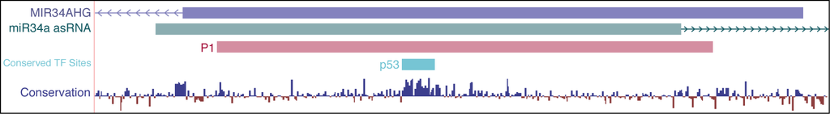

```r
url <- "P1-HCTandHEK/locusSimple.png"
knitr::include_graphics(file.path(projectUrl, url))
```

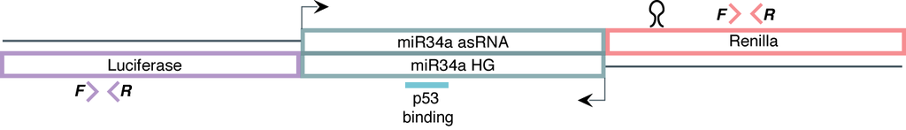

```r
url <- "P1-HCTandHEK/constructSimple.png"
knitr::include_graphics(file.path(projectUrl, url))
```

```r
url <- "P1-HCTandHEK.rda"
repmis::source_data(file.path(dataUrl, url))
```

```
## SHA-1 hash of the downloaded data file is:
## cec9138dee1f4183d9dbfc1f039a11b3024232fd
```

```
## [1] "."
```

```r
data <- .

.calcP <- function(`Cell line`, gene, value, data) {
  bool1 <- pull(data, `Cell line`) == `Cell line`
  bool2 <- pull(data, gene) == gene
  bool3 <- pull(data, construct) == "Empty"
  bool <- bool1 & bool2 & bool3
  t.test(value, pull(data, value)[bool])$p.value
}

stats <- data %>%
  group_by(`construct`, `Cell line`, gene) %>%
  summarize(
    n = n(),
    mean = mean(value),
    CI95l = t.test(value)$conf.int[1],
    CI95h = t.test(value)$conf.int[2],
    pValue = .calcP(`Cell line`, gene, value, data)
  ) %>%
  ungroup() %>%
  pFormat(.)
```

[figure not shown]

```r
data <- filter(data, construct %in% c("p1", "Empty"))
stats <- filter(stats, construct %in% c("p1", "Empty"))

#plot for Rmarkdown
ggplot(data = NULL) +
  geom_violin(
    data = data,
      aes(x = construct, y = value, fill = gene),
      trim = TRUE,
      alpha = 0.3,
      color = NA,
      scale = "width",
      show.legend = FALSE
  ) +
  geom_point(
    data = data,
    aes(x = construct, y = value, colour = gene),
    size = 4,
    position = position_dodge(width = 0.9),
    stroke = 0
  ) +
  facet_grid(. ~ `Cell line`) +
  geom_linerange(
    data = stats,
    aes(x = construct, ymin = CI95l, ymax = CI95h, group = gene),
    colour = "black",
    position = position_dodge(width = 0.9),
    show.legend = FALSE
  ) +
  geom_point(
    data = stats,
    aes(x = construct, y = mean, group = gene),
    colour = "black",
    position = position_dodge(width = 0.9),
    show.legend = FALSE
  ) +
  geom_label(
    data = stats,
    aes(x = construct, y = CI95h + 1900, label = pFormat, group = gene),
    label.size = 0,
    label.padding = unit(0.01, "lines"),
    show.legend = FALSE,
    fill = "white",
    size = 5,
    family = "Arial Unicode MS",
    position = position_dodge(width = 0.9)
  ) +
  labs(
    x = "Construct",
    y = "Activity (a.u.)",
    title = "miR34a asRNA regulation by miR34a promoter",
    caption =
            "miR34a asRNA and miR34a HG levels in HCT116 and HEK293t cells after transfection with P1 and P2 constructs.\nLuciferase represents miR34a HG and renilla represents miR34a asRNA.\nError bars (black vertical) indicate 95% CI and means are represented \nby black dots."
    ) +
  theme_few() +
  scale_fill_ptol() +
  scale_colour_ptol() +
  theme(
    plot.title = element_text(
      hjust = 0.5,
      face = "bold",
      size = 20
    ),
    plot.caption = element_text(
      hjust = 0,
      margin = margin(t = 15),
      family = "Arial Unicode MS"
    ),
    legend.position = "top",
    legend.title = element_text(size = 17),
    legend.text = element_text(size = 15),
    axis.title = element_text(size = 17),
    axis.title.x = element_text(margin = margin(t = 10)),
    axis.text = element_text(size = 15),
    strip.text.x = element_text(size = 17)
  ) +
  guides(color = guide_legend(title = "Gene", override.aes = list(size = 3)))
```

### Figure 2d

#### Introduction

Our previous results showed that miR34a HG and asRNA are simultaneously up-regulated in response to doxorubicin treatment leading us to consider the possibility that miR34a asRNA may be necessary for an appropriate miR34a response to apoptotic signaling. To explore this possibility we again utilized the p1 construct, co-transfecting it with an shRNA targeting renilla, and treating HCT116 cells with increasing levels of doxorubicin.

#### Methods

We utilized the P1 construct where the overlapping region of miR34a HG and miR34a AS is cloned with luciferase downstream of miR34a HG and renilla downstream of miR34a AS. The p1 sequence was previously published in Raver-Shapira, N., et al., Transcriptional activation of miR-34a contributes to p53-mediated apoptosis. Mol Cell, 2007. 26(5): p. 731-43. All cell lines were cultured at 5% CO2 and 37° C with HCT116 cells cultured in McCoy’s 5a (Life Technologies). All growth mediums were supplemented with 10% heat-inactivated FBS and 50 μg/ml of streptomycin and 50 μg/ml of penicillin. 2.5x10^5 HCT116wt cells were seeded in a 12-well plate. After 24hrs these were co-transfected with the P1 construct (25ng) and shRenilla2.1 (250ng) using lipo2000 (Life Technologies) standard protocol. 24hrs post-transfection, doxorubicin treatment was initiated using 0, 300, or 500ng/ml. 24hrs post-treatment, RNA was extracted using the RNeasy mini kit (Qiagen) and subsequently treated with DNase (Ambion Turbo DNA-free, Life Technologies). 500ng RNA was used for cDNA synthesis using MuMLV (Life Technologies) and a 1:1 mix of oligo(dT) and random nanomers. QPCR was carried out using KAPA 2G SYBRGreen (Kapa Biosystems) using the Applied Biosystems 7900HT machine with the cycling conditions: 95 °C for 3 min, 95 °C for 3 s, 60 °C for 30 s.

##### Constructs

```r
library(printr)
p1 <- data.frame(
    name="p1",
    sequence="GCG CCC TGC CTG GCC CCC ACC TGG TCC TCT TTC CTT TTC AGG TGG AGG AGA TGC CGC TGT
              CCC GTC GGT CTG GGG ACA GCC CAG CTC CCC GGA TCC CGG GCT GGA GAG ACG CGT CGC GGC
              CCC GGG GCC TGG TGG CAC GAG CAG GAA GGA GGA CCC GGC GGC GGG CTC TGC CTG GGC TTG
              CCT GGG CTT GTT CCG AGC CGG GCT GCT TCT CGG TGA CCA CGC AGA TCG GGG GCA TTT GGA
              GAT TTT GCG GGA GTC CTG CAG CCA AGC TCC GGG GCA GGA GAG GCC TGG AAG CCT GCA CTA
              CCT GCT C"
)
p1
```

| name | sequence |
| --- | --- |
| p1 | GCG CCC TGC CTG GCC CCC ACC TGG TCC TCT TTC CTT TTC AGG TGG AGG AGA TGC CGC TGT |
|  | CCC GTC GGT CTG GGG ACA GCC CAG CTC CCC GGA TCC CGG GCT GGA GAG ACG CGT CGC GGC |
|  | CCC GGG GCC TGG TGG CAC GAG CAG GAA GGA GGA CCC GGC GGC GGG CTC TGC CTG GGC TTG |
|  | CCT GGG CTT GTT CCG AGC CGG GCT GCT TCT CGG TGA CCA CGC AGA TCG GGG GCA TTT GGA |
|  | GAT TTT GCG GGA GTC CTG CAG CCA AGC TCC GGG GCA GGA GAG GCC TGG AAG CCT GCA CTA |
|  | CCT GCT C |

##### shRNAs

```r
shRNAs <- data.frame(
    name=c(
        "shRenilla2.1"
    ),
    sequence=c(
        "TAA CGG GAT TTC ACG AGG C"
    )
)
shRNAs
```

| name | sequence |
| --- | --- |
| shRenilla2.1 | TAA CGG GAT TTC ACG AGG C |

##### Primers

```r
primers <- data.frame(
    name=c(
        "Luc_set_II_F",
        "Luc_set_II_R",
        "Renilla_pBiDir_F1",
        "Renilla_pBiDir_R1",
        "B-actin_F",
        "B-actin_R"
    ),
    sequence=c(
        "AAG ATT CAA AGT GCG CTG CTG",
        "TTG CCT GAT ACC TGG CAG ATG",
        "TAA CGC GGC CTC TTC TTA TTT",
        "GAT TTG CCT GAT TTG CCC ATA",
        "AGG TCA TCA CCA TTG GCA ATG AG",
        "CTT TGC GGA TGT CCA CGT CA"
    )
)
primers
```

| name | sequence |
| --- | --- |
| Luc_set_II_F | AAG ATT CAA AGT GCG CTG CTG |
| Luc_set_II_R | TTG CCT GAT ACC TGG CAG ATG |
| Renilla_pBiDir_F1 | TAA CGC GGC CTC TTC TTA TTT |
| Renilla_pBiDir_R1 | GAT TTG CCT GAT TTG CCC ATA |
| B-actin_F | AGG TCA TCA CCA TTG GCA ATG AG |
| B-actin_R | CTT TGC GGA TGT CCA CGT CA |

#### Results

```r
url <- "p1shRNAdox.rda"
repmis::source_data(file.path(dataUrl, url))
```

```
## SHA-1 hash of the downloaded data file is:
## c41f628771e1915efb384c6483bc6cf6461d572e
```

```
## [1] "."
```

```r
data <- .

#Luciferase = miR34a HG
#Renilla = miR34a AS

#calculate dct
groups <- c("treatment", "Biological Replicate", "shRNA", "gene")
gois <- c("Luciferase", "Renilla")

data <- data %>%
  technicalMeans(., groups) %>%
  dct(., gois, Actin, groups)

#calculate ddct
groups[groups == "gene"] <- "GOI"
logical <- tibble(
  `shRNA` = pull(data, shRNA) == "shRNA Control"
)

data <- data %>%
  ddct(., logical, groups) %>%
  folds(.)

#calculate stats
stats <- calcStats(data, shRNA, "shRNA Control", groups) %>%
  pFormat(.)

#prepare for plotting
data <- data %>%
  mutate(plotGOI = case_when(
    GOI == "Luciferase" ~ "  Luciferase\n(miR34a HG)",
    GOI == "Renilla" ~ "       Renilla\n(miR34a asRNA)"
  ))

stats <- stats %>%
  mutate(plotGOI = case_when(
    GOI == "Luciferase" ~ "  Luciferase\n(miR34a HG)",
    GOI == "Renilla" ~ "       Renilla\n(miR34a asRNA)"
  ))
```

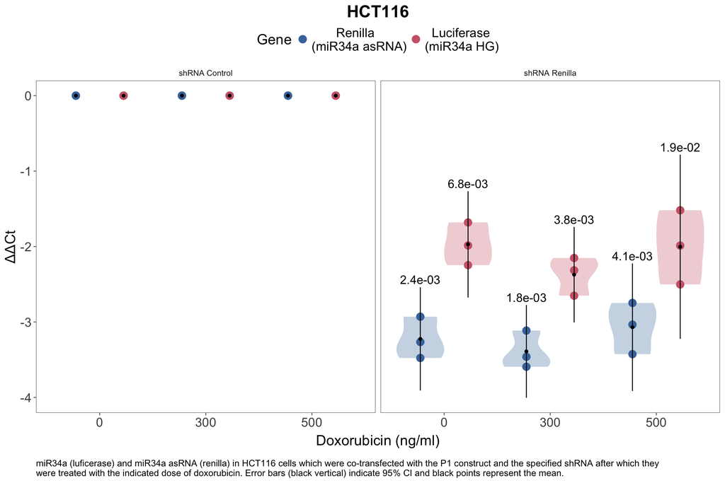

```r
#plot for rmarkdown
ggplot(data = NULL) +
  geom_violin(
    data = data,
    aes(x = treatment, y = log2fold, fill = plotGOI),
    trim=TRUE,
    scale="width",
    alpha=0.3,
    colour=NA,
    show.legend = FALSE
  ) +
  geom_point(
    data = data,
    aes(x = treatment, y = log2fold, colour = plotGOI),
    size = 4,
    position = position_dodge(width = 0.9)
  ) +
  facet_grid(. ~ shRNA, scale = "free") +
  geom_linerange(
    data = stats,
    aes(x = treatment, ymin = CI95l, ymax = CI95h, group = plotGOI),
    colour = "black",
    position = position_dodge(width = 0.9),
    show.legend = FALSE
  ) +
  geom_point(
    data = stats,
    aes(x = treatment, y = mean, group = plotGOI),
    colour = "black",
    position = position_dodge(width = 0.9),
    show.legend = FALSE
  ) +
  geom_label(
    data = stats,
    aes(x = treatment, y = CI95h + 0.1, label = pFormat, group = plotGOI),
    label.size = 0,
    label.padding = unit(0.01, "lines"),
    show.legend = FALSE,
    position = position_dodge(width = 0.9),
    fill = "white",
    size = 5,
    family = "Arial Unicode MS"
  ) +
  scale_y_continuous("\u0394\u0394Ct") +
  labs(
    x = "Doxorubicin (ng/ml)",
    title = "HCT116",
    caption =
            "miR34a (luficerase) and miR34a asRNA (renilla) in HCT116 cells which were co-transfected with the P1 construct and the specified shRNA after which they\nwere treated with the indicated dose of doxorubicin. Error bars (black vertical) indicate 95% CI and black points represent the mean."
  ) +
  theme_few() +
  scale_fill_ptol() +
  scale_color_ptol() +
  theme(
    plot.title = element_text(
      hjust = 0.5,
      face = "bold",
      size = 20
    ),
    plot.caption = element_text(
      hjust = 0,
      margin = margin(t = 15),
      family = "Arial Unicode MS"
    ),
    legend.position = "top",
    legend.title = element_text(size = 17),
    legend.text = element_text(size = 15, hjust = 0.5),
    axis.title = element_text(size = 17),
    axis.title.x = element_text(margin = margin(t = 10)),
    axis.text = element_text(size = 15)
  ) +
  guides(
    color = guide_legend(
      title = "Gene",
      override.aes = list(size = 4)
    )
  )
```

#### Conclusion

Levels of luciferase were abrogated in the shRenilla-transfected cells compared to control shRNA-transfected cells. Collectively, these results indicate that miR34a asRNA positively regulates levels of miR34a HG and is crucial for a proper miR34a response to apoptotic stimuli.

### Figure 3a

#### Introduction

We hypothesized that miR34a asRNA may function to mediate the levels of its sense gene, miR34a. To this end, we stably over-expressed miR34a asRNA, using lentiviral transduction, in 3 different p53-null cell lines and monitored the effects on miR34a.

#### Methods

##### miR34a asRNA cloning

RNA was harvested from U2OS cells using the RNeasy mini kit (Qiagen) and subsequently treated with DNase (Ambion Turbo DNA-free, Life Technologies). 500ng RNA was used for cDNA synthesis using MuMLV (Life Technologies) and a 1:1 mix of oligo(dT) and random nanomers. PCR was run using the miR34aAS_cloning_F4 and miR34aAS_cloning_Ex3_1 primers for 40 cycles at annealing temperature 58˚C and run on an agarose gel. Bands were excised and extracted using the QIAquick gel extraction kit (Qiagen). PCR products were cloned using the Strata Clone kit (Aligent) and sequenced (results below). The insert for the lentiviral construct (p-HIV-I2AG-U6) was subsequently sub-cloned from the sequenced plasmid using primers with PacI and NheI cleavage sites. The cloned transcript largley mirrors the GENCODE annotated transcript.

###### Cloning primers

```r
library(printr)
primers <- data.frame(
    name=c(
        "miR34aAS_cloning_F4",
        "miR34aAS_cloning_Ex3_1"
    ),
    sequence=c(
        "ACGCGTCTCTCCAGCCCGGGAT",
        "AATGATGGCCGCAACTAATGACGG"
    )
)
primers
```

| name | sequence |
| --- | --- |
| miR34aAS_cloning_F4 | ACGCGTCTCTCCAGCCCGGGAT |
| miR34aAS_cloning_Ex3_1 | AATGATGGCCGCAACTAATGACGG |

###### Sequencing results

```r
construct <- data.frame(
    name="miR34a_asRNA",
    sequence="ACG CGT CTC TCC AGC CCG GGA TCC GGG GAG CTG GGC TGT CCC CAG ACC GAC GGG ACA GCG GCA
                TCT CCT CCA CCT GAA AAG GAA AGA GGA CCA GTT TGC AGG ACT CCG AAC TGG GCC CGC GAG ATC
                TCC ACC TGC GCA AAA CGA AAG GGC GGA TTC TCC TTG GAC TCA CGA GGC AAC CGC TCC CCG GGG
                TGA GAA CGG GGG ACT CAT TCC TCC GGC ACT GGG AGA AGA CGA TTC TTC AGG AGG AGG ACA GGG
                AAG CGA ATG CTA CCC AGA TGT CTC AGT ATA CTG GCT CGC GGC ACA TCG GGC AAA TGA ACC TAT
                CAG ATA ACA ACG GCA GAT CAG ATG CCT GAG CAT TCA GAA GCA ACA GCT GTG GAG CCC CCG TGG
                GTT CAG AAG GCC TGG TTC CCG TCT CCA GAA GCC TGG CTC TCC TCC CTC CTG GGC CCA CTA CTT
                TGG CTT CTT GTT CCT ACG TAC AAG GAG TTG CGA AGA AGG CAA CTC TTC CCC TCC CTG AAG CCA
                AAG GAA TGA AAC AGA CTA GGG CGG GAG AGG TGG CCA TCC GTC ATT AGT TGC GGC CAT CA"
)
construct
```

| name | sequence |
| --- | --- |
| miR34a_asRNA | ACG CGT CTC TCC AGC CCG GGA TCC GGG GAG CTG GGC TGT CCC CAG ACC GAC GGG ACA GCG GCA |
|  | TCT CCT CCA CCT GAA AAG GAA AGA GGA CCA GTT TGC AGG ACT CCG AAC TGG GCC CGC GAG ATC |
|  | TCC ACC TGC GCA AAA CGA AAG GGC GGA TTC TCC TTG GAC TCA CGA GGC AAC CGC TCC CCG GGG |
|  | TGA GAA CGG GGG ACT CAT TCC TCC GGC ACT GGG AGA AGA CGA TTC TTC AGG AGG AGG ACA GGG |
|  | AAG CGA ATG CTA CCC AGA TGT CTC AGT ATA CTG GCT CGC GGC ACA TCG GGC AAA TGA ACC TAT |
|  | CAG ATA ACA ACG GCA GAT CAG ATG CCT GAG CAT TCA GAA GCA ACA GCT GTG GAG CCC CCG TGG |
|  | GTT CAG AAG GCC TGG TTC CCG TCT CCA GAA GCC TGG CTC TCC TCC CTC CTG GGC CCA CTA CTT |
|  | TGG CTT CTT GTT CCT ACG TAC AAG GAG TTG CGA AGA AGG CAA CTC TTC CCC TCC CTG AAG CCA |
|  | AAG GAA TGA AAC AGA CTA GGG CGG GAG AGG TGG CCA TCC GTC ATT AGT TGC GGC CAT CA |

##### Lentivirus production and infection

HEK293T cells were transfected with viral and expression constructs using Lipofectamine 2000 (Life Technologies), after which viral supernatants were harvested 48 and 72 hours post-transfection. Viral particles were concentrated using PEG-IT solution (Systems Biosciences) according to the manufacturer’s recommendations. HEK293T cells were used for virus titration and GFP expression was evaluated 72hrs post-infection via flow cytometry after which TU/ml was calculated. Cell lines were subsequently infected with the lentiviral particals using a multuplicity of infection = 1. After 48 hours, cells were placed under mycophenolic acid selection and the selection process was monitored using GFP expression via flow cytometry. When GFP expression was present in >90% of the cells, cells were frozen for downstream analysis.

##### QPCR

RNA was extracted using the RNeasy mini kit (Qiagen) and subsequently treated with DNase (Ambion Turbo DNA-free, Life Technologies). 500ng RNA was used for cDNA synthesis using MuMLV (Life Technologies) and a 1:1 mix of oligo(dT) and random nanomers. QPCR was carried out using KAPA 2G SYBRGreen (Kapa Biosystems) using the Applied Biosystems 7900HT machine with the cycling conditions: 95 °C for 3 min, 95 °C for 3 s, 60 °C for 30 s. QPCR for miRNA expression analysis was performed according to the protocol for the TaqMan microRNA Assay kit (Life Technologies) with primer/probe sets purchased from the same company (TaqMan® MicroRNA Assay, hsa-miR-34a, human and Control miRNA Assay, RNU48, human) and the same cycling scheme as above.

###### QPCR primers

```r
###Q-PCR primers
primers <- data.frame(
    name=c(
        "ß-actin Fwd",
        "ß-actin Rev",
        "miR34a_asF1",
        "miR34a_asR1"

    ),
    sequence=c(
        "AGGTCATCACCATTGGCAATGAG",
        "CTTTCGGGATGTCCACGTCA",
        "AGCGGCATCTCCTCCACCTGAAA",
        "TTGCCTCGTGAGTCCAAGGAGAAT"

    )
)
primers
```

| name | sequence |
| --- | --- |
| ß-actin Fwd | AGGTCATCACCATTGGCAATGAG |
| ß-actin Rev | CTTTCGGGATGTCCACGTCA |
| miR34a_asF1 | AGCGGCATCTCCTCCACCTGAAA |
| miR34a_asR1 | TTGCCTCGTGAGTCCAAGGAGAAT |

#### Results

```r
url <- "stableLineExpression.rda"
repmis::source_data(file.path(dataUrl, url))
```

```
## [1] "."
```

```r
data <- .

#remove Skov exp 1 due to variability in technical replicates
data <- filter(data, `Biological Replicate` != 1 | `Cell line` != "Skov3")

#Have to divide the analysis due to the presence of several house
#keeping genes.
gois1 <- c("miR34a asRNA", "Actin")
gois2 <- c("miR34a", "RNU48")
data1 <- filter(data, gene %in% gois1)
data2 <- filter(data, gene %in% gois2)

#calculate dct
groups <- c("Genetic mod", "Biological Replicate", "Cell line", "gene")

data1 <- data1 %>%
  technicalMeans(., groups) %>%
  dct(., gois1, Actin, groups) %>%
  mutate(GOI = as.character(GOI))

data2 <- data2 %>%
  technicalMeans(., groups) %>%
  dct(., gois2, RNU48, groups) %>%
  mutate(GOI = as.character(GOI))

data <- bind_rows(data1, data2) %>%
  mutate(GOI = parse_factor(GOI, levels = c("miR34a asRNA", "miR34a")))

#calculate ddct
groups[groups == "gene"] <- "GOI"
logical <- tibble(
  `Biological Replicate` = pull(data, `Biological Replicate`) == 2,
  `Genetic mod` = pull(data, `Genetic mod`) == "mock"
)

data <- data %>%
  ddct(., logical, groups) %>%
  folds(.)

#calculate stats
stats <- calcStats(data, `Genetic mod`, "mock", groups) %>%
  pFormat(.)

#format for plotting
lev <- c("PC3\nmock", "PC3\nmiR34a asRNA", "Skov3\nmock", "Skov3\nmiR34a asRNA", "Saos2\nmock",   "Saos2\nmiR34a asRNA")

data <- data %>%
  mutate(Condition = paste(`Cell line`, `Genetic mod`, sep = "\n")) %>%
  mutate(Condition = parse_factor(Condition, levels = lev))

stats <- stats %>%
  mutate(Condition = paste(`Cell line`, `Genetic mod`, sep = "\n")) %>%
  mutate(Condition = parse_factor(Condition, levels = lev))
```

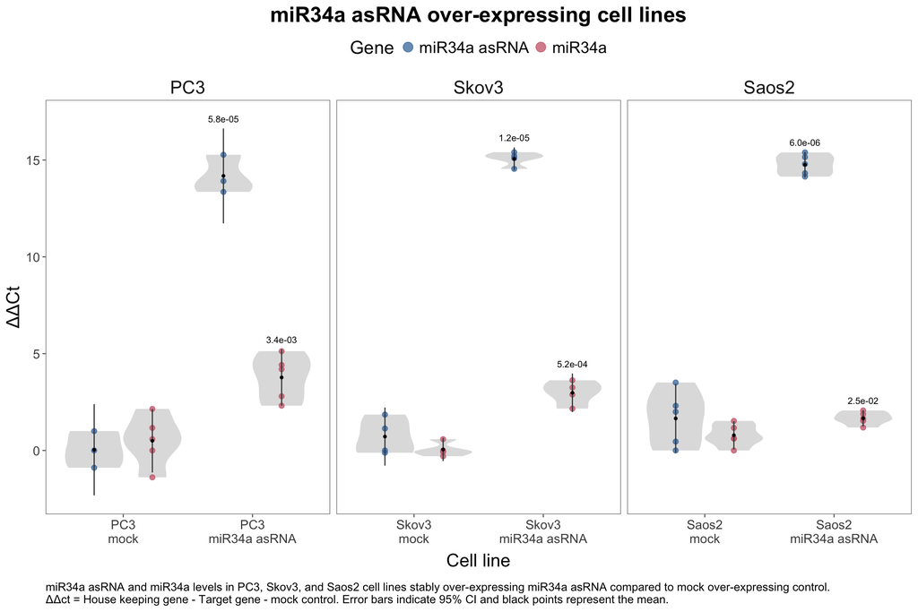

```r
#plot for rmarkdown
ggplot(data = NULL)+
  geom_violin(
    data = data,
    aes(x = Condition, y = log2fold, group = interaction(Condition, GOI)),
    trim=TRUE,
    alpha=0.5,
    fill="grey",
    colour=NA,
    scale="width",
    show.legend = FALSE
  ) +
  geom_point(
    data = data,
    aes(x = Condition, y = log2fold, colour = GOI, group = interaction(Condition, GOI)),
    size = 2,
    alpha = 0.75,
    position = position_dodge(width = 0.9)
  ) +
  facet_grid(
    . ~ `Cell line`,
    scales = "free",
    space = "free"
  ) +
  geom_linerange(
    data = stats,
    aes(x = Condition, ymin = CI95l, ymax = CI95h, group = interaction(Condition, GOI)),
    position = position_dodge(width = 0.9),
    colour = "grey25",
    show.legend = FALSE
  ) +
  geom_point(
    data = stats,
    aes(x = Condition, y=mean, group = interaction(Condition, GOI)),
    colour = "black",
    size = 1,
    position = position_dodge(width = 0.9),
    show.legend = FALSE
  ) +
  geom_label(
    data = stats,
    aes(x = Condition, y = CI95h + 0.5, label = pFormat, group = interaction(Condition, GOI)),
    fill = "white",
    label.size = 0,
    label.padding = unit(0.01, "lines"),
    position = position_dodge(width = 0.9),
    show.legend = FALSE,
    fontface = "bold",
    family = "Arial Unicode MS",
    size = 3
  ) +
  scale_y_continuous("\u0394\u0394Ct")+
  labs(
    x = "Cell line",
    title = "miR34a asRNA over-expressing cell lines",
    caption =
            "miR34a asRNA and miR34a levels in PC3, Skov3, and Saos2 cell lines stably over-expressing miR34a asRNA compared to mock over-expressing control.\n\u0394\u0394ct = House keeping gene - Target gene - mock control. Error bars indicate 95% CI and black points represent the mean."
  )+
  theme_few() +
  scale_colour_ptol() +
  theme(
    legend.position = "top",
    legend.title = element_text(size = 17),
    legend.text = element_text(size = 15),
    plot.title = element_text(
      hjust = 0.5,
      face = "bold",
      size = 20
    ),
    plot.caption = element_text(
      hjust = 0,
      margin = margin(t = 15),
      family = "Arial Unicode MS"
    ),
    axis.title = element_text(size = 17),
    axis.title.x = element_text(margin = margin(t = 10)),
    axis.text = element_text(size = 12),
    strip.text.x = element_text(size = 17)
  )+
  guides(
    color = guide_legend(title = "Gene", override.aes = list(size = 4)))
```

#### Conclusion

miR34a asRNA over-expression causes a concominant up-regulation of miR34a in all 3 cell lines. This indicates that miR34a asRNA concordantly regulates miR34a.